# STAT656: Homework 1

Analyzing Airline Flight Delays.

# Introduction and Data

We will be analyzing airline flight delays. Note that this Rmd file will not knit in its current form. It is necessary to complete some of the below items for it to knit successfully.

## Download

The first step in this assignment will be downloading the flight data from the [Bureau of Transportation Statistics](https://www.transtats.bts.gov/DL_SelectFields.asp?gnoyr_VQ=FGJ&QO_fu146_anzr=b0-gvzr)

Here are some instructions (this will take some time, make sure one is done downloading before starting the next one. It took me about 17 minutes to casually do this while I did other things):

- Set “Filter Year” to 2023
- Set “Filter Period” to January
- Select the following fields:
  - Month
  - DayofMonth
  - DayofWeek
  - FlightDate
  - Reporting_Airline
  - DOT_ID_Reporting_Airline
  - OriginAirportID
  - OriginCityMarketID
  - Origin
  - OriginCityName
  - OriginState
  - DestAirportID
  - DestCityMarketID
  - Dest
  - DestCityName
  - DestState
  - DepDelay
  - DepDel15
  - ArrDelay
  - ArrDel15
  - Cancelled
  - CancellationCode
- Click “Download”
- Change the “Filter Period” to February and Click “Download”
- Change the “Filter Period” to March and Click “Download”
- …
- Change the “Filter Period” to December and Click “Download”

## Uncompress and rename

Now, go to wherever your operating system defaults to downloading, more than likely your ‘download’ directory. There will be 12 .zip files there. Uncompress each of these files.

## Move the files

Make a subdirectory of your R working directory (the working directory is where your .Rmd file is located) called “database”. I suggest making a folder homework1 or some such, and making database a subdirectory.

Now, we want to run the following code to generate an R object that is a single flat file containing all the flights for that year.

## Let’s load in some packages.

```r
require(tidyverse)
```

# Problem 0 (20 pts)

Now, we want to take the data and make a data set. First, let’s get the file names from the database directory

```r
setwd(here::here())

paths = dir("database",pattern="T_ONTIME_REPORTING",full.names=TRUE)
print(paths)
```

```
##  [1] "database/T_ONTIME_REPORTING_20260918_133443.csv"
##  [2] "database/T_ONTIME_REPORTING_20260918_133517.csv"
##  [3] "database/T_ONTIME_REPORTING_20260918_133550.csv"
##  [4] "database/T_ONTIME_REPORTING_20260918_133628.csv"
##  [5] "database/T_ONTIME_REPORTING_20260918_133706.csv"
##  [6] "database/T_ONTIME_REPORTING_20260918_133741.csv"
##  [7] "database/T_ONTIME_REPORTING_20260918_133815.csv"
##  [8] "database/T_ONTIME_REPORTING_20260918_133924.csv"
##  [9] "database/T_ONTIME_REPORTING_20260918_140001.csv"
## [10] "database/T_ONTIME_REPORTING_20260918_140036.csv"
## [11] "database/T_ONTIME_REPORTING_20260918_140126.csv"
## [12] "database/T_ONTIME_REPORTING_20260918_140203.csv"
```

```r
names(paths) = basename(paths)

dfList = lapply(paths, read.csv)
allColumns = unique(unlist(lapply(dfList, names)))

data.frame(
  file = basename(paths),
  ncol = sapply(dfList, ncol),
  missingColumns = sapply(
    dfList,
    function(x) sum(!allColumns %in% names(x))
  )
)
```

```
##                                                                          file
## T_ONTIME_REPORTING_20260918_133443.csv T_ONTIME_REPORTING_20260918_133443.csv
## T_ONTIME_REPORTING_20260918_133517.csv T_ONTIME_REPORTING_20260918_133517.csv
## T_ONTIME_REPORTING_20260918_133550.csv T_ONTIME_REPORTING_20260918_133550.csv
## T_ONTIME_REPORTING_20260918_133628.csv T_ONTIME_REPORTING_20260918_133628.csv
## T_ONTIME_REPORTING_20260918_133706.csv T_ONTIME_REPORTING_20260918_133706.csv
## T_ONTIME_REPORTING_20260918_133741.csv T_ONTIME_REPORTING_20260918_133741.csv
## T_ONTIME_REPORTING_20260918_133815.csv T_ONTIME_REPORTING_20260918_133815.csv
## T_ONTIME_REPORTING_20260918_133924.csv T_ONTIME_REPORTING_20260918_133924.csv
## T_ONTIME_REPORTING_20260918_140001.csv T_ONTIME_REPORTING_20260918_140001.csv
## T_ONTIME_REPORTING_20260918_140036.csv T_ONTIME_REPORTING_20260918_140036.csv
## T_ONTIME_REPORTING_20260918_140126.csv T_ONTIME_REPORTING_20260918_140126.csv
## T_ONTIME_REPORTING_20260918_140203.csv T_ONTIME_REPORTING_20260918_140203.csv
##                                        ncol missingColumns
## T_ONTIME_REPORTING_20260918_133443.csv   25              0
## T_ONTIME_REPORTING_20260918_133517.csv   25              0
## T_ONTIME_REPORTING_20260918_133550.csv   25              0
## T_ONTIME_REPORTING_20260918_133628.csv   25              0
## T_ONTIME_REPORTING_20260918_133706.csv   25              0
## T_ONTIME_REPORTING_20260918_133741.csv   25              0
## T_ONTIME_REPORTING_20260918_133815.csv   25              0
## T_ONTIME_REPORTING_20260918_133924.csv   25              0
## T_ONTIME_REPORTING_20260918_140001.csv   25              0
## T_ONTIME_REPORTING_20260918_140036.csv   25              0
## T_ONTIME_REPORTING_20260918_140126.csv   25              0
## T_ONTIME_REPORTING_20260918_140203.csv   25              0
```

#### Answer 0.1

What does ‘basename’ do here?

basename name is a function that extracts the final file or directory name from a full file path by stripping away all leading directory components.

## Creating the data set

This next step can take a few minutes. Let’s time it! Accurately timing code is extremely delicate and controversial because it depends on all the settings on your computer, what other programs you have running, architecture (do you have multiple cores/processors/…) even how long it has been since you rebooted!

But, a simple and useful way is via `proc.time’, which records the computer time of your processor. Let’s read in each .csv file into an R data file that has all of the flights.

(note: we will use ‘cache = TRUE’ so that R studio won’t re-compile this section every time you knit. It will detect any changes to this `chunk’ and re-run if there are any. However, it doesn’t detect if there are changes in another chunk that affects this chunk. For that, we need ‘dependson’. In this case, a change to the directory database would affect ‘df’. So, we want to add ‘dependson’ pointed to that chunk. Note that each dependson chunk must be cached as well)

```r
srt    = proc.time()[3]
dfList = lapply(paths,read.csv)
df     = do.call(rbind,dfList)
end    = proc.time()[3]

df$X = NULL #get rid of that empty column
save(df, file="2023flights.Rdata")

totalTime = end - srt #### Answer 0.2 ## Overwrite the totalTime object so that it has the correct elapsed time
```

Answer: This process took 31.64 seconds. (this is how you write answers ‘inline’ in R Markdown)

## The data set

Let’s look at some attributes of this data set

```r
dataSetSize = format(object.size(df),units='MiB')
```

#### Answer 0.3

The total size of the flights data set for that year is 1724.2 MiB

(Use inline code as the previous answer (don’t just ‘hard code’ the value))

Also, it is a good opportunity to make sure you have the complete data set. For instance, check to make sure you have the correct number of months: I have 4, 5, 6, 7, 8, 9, 10, 11, 1, 2, 3, 12 months out of the expected 12 total months.

# Problem 1 (20 pts)

Some of the flights were cancelled and hence never flew. These are recorded via the ‘cancelled’ feature. How many total flights are there in the data set? How many were cancelled?

Additionally, there are some missing values, coded as NA, in the data set. Generally, we would want to impute these missing values. However, we will return to imputation later in the semester. For now, let’s remove the rows (flights) with missing values. Make a new object called flightsNotCancelled that have the flights that were not cancelled and have no missing values. Make sure to use this for the rest of the assignment. Lastly, how many flights do we have remaining in flightsNotCancelled?

```r
totalNum  = nrow(df)
cancelNum =  df %>%
  group_by(CANCELLED) %>% #### Answer 1.1 ## Insert the correct group_by statement here
summarise(n = n())

#I just want the integer, not the tibble:
cancelNum = as.integer(cancelNum[2,2])

flightsNotCancelled = df %>%
  filter(CANCELLED == 0) %>% #### Answer 1.2  Insert the correct filter statement here
  na.omit(.)
```

#### Answer 1.3

**make sure you complete this answer dynamically (i.e. don’t hardcode in the answer, use object names)**

The total number of flights is 6847899 . The total number of cancelled flights is 87943 . The total number of flights remaining after removing NAs is 6743403

# Problem 2 (15 pts)

How many flights were there for each day of the week?

```r
flightsPerDay = flightsNotCancelled %>%
  group_by(DAY_OF_WEEK) %>%
  summarize(total = n())

flightsPerDay
```

```
## # A tibble: 7 × 2
##   DAY_OF_WEEK   total
##         <int>   <int>
## 1           1  996633
## 2           2  937570
## 3           3  951327
## 4           4  998363
## 5           5 1003622
## 6           6  870955
## 7           7  984933
```

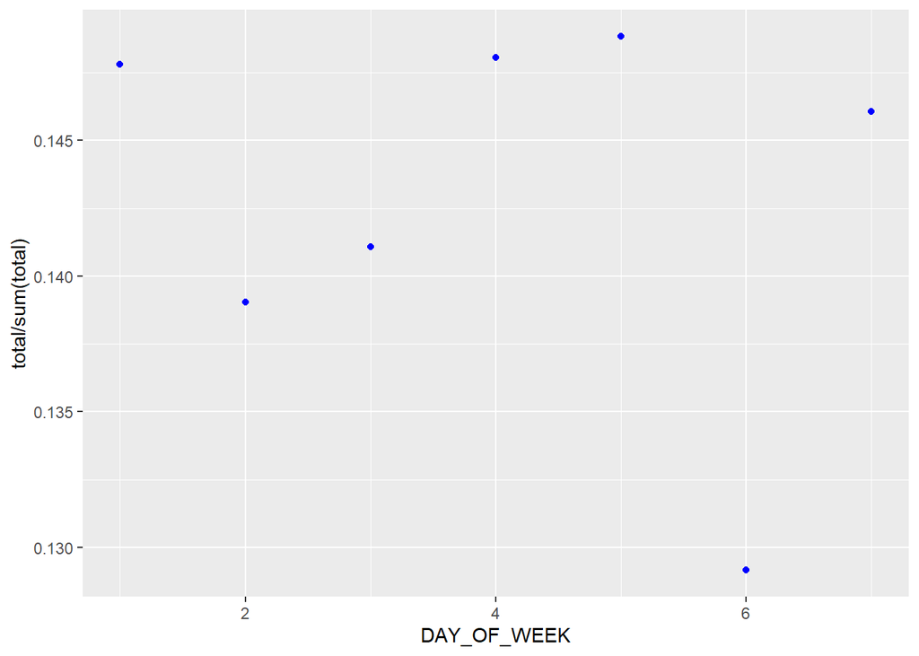

```r
ggplot(data = flightsPerDay) +
  geom_point(
    aes(x = DAY_OF_WEEK, y = total / sum(total)),
    color = "blue"
  )
```

```r
#### Answer 2.1 ## Alter this plot so that the points are blue and the plot is of the proportion of flights each day instead of total
```

# Problem 3 (20 pts)

Which month has the greatest proportion of late flights?

```r
props = flightsNotCancelled %>%
  mutate(delayInd = ifelse(DEP_DELAY > 0,1,0)) %>%
  #### Answer 3.1 Fill in the missing part
  group_by(MONTH) %>%
  summarize(total = n(),success = sum(delayInd),prop = mean(delayInd))

props
```

```
## # A tibble: 12 × 4
##    MONTH  total success  prop
##    <int>  <int>   <dbl> <dbl>
##  1     1 527197  201853 0.383
##  2     2 492747  173594 0.352
##  3     3 571533  231750 0.405
##  4     4 550249  220144 0.400
##  5     5 575429  208204 0.362
##  6     6 562804  255901 0.455
##  7     7 585058  276357 0.472
##  8     8 592142  233023 0.394
##  9     9 560887  197191 0.352
## 10    10 596003  195860 0.329
## 11    11 562413  171418 0.305
## 12    12 566941  190463 0.336
```

```r
greatestProp = props %>%
   slice_max(order_by = prop, n = 1)
```

#### Answer 3.2

The month with the greatest proportion of late flights is month 7, with a late-flight proportion of 47.24%.

# Problem 4 (25 pts)

Which departure and arrival airport combination is associated with the worst median departure delay? Make sure the airport combination has at least 1000 recorded flights.

You’re a bit on your own here. Use the ideas from class and from this homework to answer this question. Be sure to take a look at the nature of the delay feature and see how it represents early departures. You can think of delays in two ways: with early departures (that is, negative delay) or without early departures. Explore this question a bit and see if your answer changes depending on the definition.

```r
# Definition 1: keep early departures as negative delays
delayWithEarly = flightsNotCancelled %>%
  group_by(ORIGIN, DEST, ORIGIN_CITY_NAME, DEST_CITY_NAME) %>%
  summarize(
    total = n(),
    medianDelay = median(DEP_DELAY),
    .groups = "drop"
  ) %>%
  filter(total >= 1000) %>%
  arrange(desc(medianDelay))

worstWithEarly = delayWithEarly %>%
  slice_max(order_by = medianDelay, n = 1)

worstWithEarly
```

```
## # A tibble: 1 × 6
##   ORIGIN DEST  ORIGIN_CITY_NAME DEST_CITY_NAME total medianDelay
##   <chr>  <chr> <chr>            <chr>          <int>       <dbl>
## 1 BWI    SJU   Baltimore, MD    San Juan, PR    1411           9
```

```r
# Definition 2: treat early departures as 0 delay
delayWithoutEarly = flightsNotCancelled %>%
  mutate(DEP_DELAY_NO_EARLY = pmax(DEP_DELAY, 0)) %>%
  group_by(ORIGIN, DEST, ORIGIN_CITY_NAME, DEST_CITY_NAME) %>%
  summarize(
    total = n(),
    medianDelay = median(DEP_DELAY_NO_EARLY),
    .groups = "drop"
  ) %>%
  filter(total >= 1000) %>%
  arrange(desc(medianDelay))

worstWithoutEarly = delayWithoutEarly %>%
  slice_max(order_by = medianDelay, n = 1)

worstWithoutEarly
```

```
## # A tibble: 1 × 6
##   ORIGIN DEST  ORIGIN_CITY_NAME DEST_CITY_NAME total medianDelay
##   <chr>  <chr> <chr>            <chr>          <int>       <dbl>
## 1 BWI    SJU   Baltimore, MD    San Juan, PR    1411           9
```

When early departures are retained as negative delays, the worst airport combinations are BWI to SJU, with a median departure delay of 9 minutes.

When early departures are treated as zero delay, the worst airport combinations are BWI to SJU, with a median departure delay of 9 minutes.

#### Problem 4.2

What are these two airports? Don’t answer using the airport number or 3 letter code. Instead, answer using the city/state or country of the airport.

```r
worstWithoutEarly %>%
  select(ORIGIN_CITY_NAME, DEST_CITY_NAME, medianDelay)
```

```
## # A tibble: 1 × 3
##   ORIGIN_CITY_NAME DEST_CITY_NAME medianDelay
##   <chr>            <chr>                <dbl>
## 1 Baltimore, MD    San Juan, PR             9
```

```r
# Build the "City to City" pairs dynamically for use inline below
worstPairs = paste0("**", worstWithoutEarly$ORIGIN_CITY_NAME, " to ",
                     worstWithoutEarly$DEST_CITY_NAME, "**")
worstPairsText = paste(worstPairs, collapse = " and ")
```